# Upset plot

Kirstin Purves, Tom McGregor

2020-11-17

# Executive summary

complex-upset package is really easy to use with some cool, sophisticate features. Works well in complex example provded by authors, and simple simulation of data structure we have available.

# Create code for creating an upset plot

Effectively trying to recreate the approach Kylie Glanville used here

[figure not shown]

Trying to create this to show number of people excluded from an experiment in orthogonal and overlapping grousp. Want to achieve this:

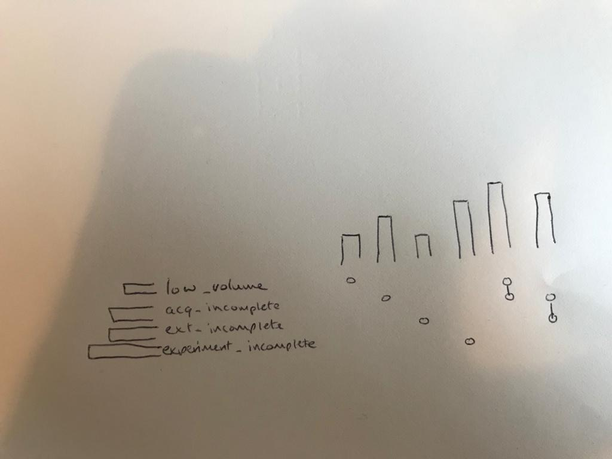

Ideal output

Bars to the left are total number who have done the thing. Bars to the top are number of people who have done a mix of the things.

# Try different packages to create plots

### Set up

Block here checks if upsetr and devtools is installed, and installs it if not. Installs complex-upset latest version from github

# UPSETR

[UpsetR package. Example here](https://www.r-graph-gallery.com/upset-plot.html).

#### Creates a names list

```r
# Dataset
input <- c(
  M.acuminata = 759,
  P.dactylifera = 769,
  A.thaliana = 1187,
  O.sativa = 1246,
  S.bicolor = 827,
  B.distachyon = 387,
  "P.dactylifera&M.acuminata" = 467,
  "O.sativa&M.acuminata" = 29,
  "A.thaliana&O.sativa" = 6,
  "S.bicolor&A.thaliana" = 9,
  "O.sativa&P.dactylifera" = 32,
  "S.bicolor&P.dactylifera" = 49,
  "S.bicolor&M.acuminata" = 49,
  "B.distachyon&O.sativa" = 547,
  "S.bicolor&O.sativa" = 1151,
  "B.distachyon&A.thaliana" = 10,
  "B.distachyon&M.acuminata" = 9,
  "B.distachyon&S.bicolor" = 402,
  "M.acuminata&A.thaliana" = 155,
  "A.thaliana&P.dactylifera" = 105,
  "B.distachyon&P.dactylifera" = 25,
  "S.bicolor&O.sativa&P.dactylifera" = 42,
  "B.distachyon&O.sativa&P.dactylifera" = 12,
  "S.bicolor&O.sativa&B.distachyon" = 2809,
  "B.distachyon&O.sativa&A.thaliana" = 18,
  "S.bicolor&O.sativa&A.thaliana" = 40,
  "S.bicolor&B.distachyon&A.thaliana" = 14,
  "O.sativa&B.distachyon&M.acuminata" = 28,
  "S.bicolor&B.distachyon&M.acuminata" = 13,
  "O.sativa&M.acuminata&P.dactylifera" = 35,
  "M.acuminata&S.bicolor&A.thaliana" = 21,
  "B.distachyon&M.acuminata&A.thaliana" = 7,
  "O.sativa&M.acuminata&A.thaliana" = 13,
  "M.acuminata&P.dactylifera&A.thaliana" = 206,
  "P.dactylifera&A.thaliana&S.bicolor" = 4,
  "O.sativa&A.thaliana&P.dactylifera" = 6,
  "S.bicolor&O.sativa&M.acuminata" = 64,
  "S.bicolor&M.acuminata&P.dactylifera" = 19,
  "B.distachyon&A.thaliana&P.dactylifera" = 3,
  "B.distachyon&M.acuminata&P.dactylifera" = 12,
  "B.distachyon&S.bicolor&P.dactylifera" = 23,
  "M.acuminata&B.distachyon&S.bicolor&A.thaliana" = 54,
  "P.dactylifera&S.bicolor&O.sativa&M.acuminata" = 62,
  "B.distachyon&O.sativa&M.acuminata&P.dactylifera" = 18,
  "S.bicolor&B.distachyon&O.sativa&A.thaliana" = 206,
  "B.distachyon&M.acuminata&O.sativa&A.thaliana" = 29,
  "O.sativa&M.acuminata&A.thaliana&S.bicolor" = 71,
  "M.acuminata&O.sativa&P.dactylifera&A.thaliana" = 28,
  "B.distachyon&M.acuminata&O.sativa&A.thaliana" = 7,
  "B.distachyon&S.bicolor&P.dactylifera&A.thaliana" = 11,
  "B.distachyon&O.sativa&P.dactylifera&A.thaliana" = 5,
  "A.thaliana&P.dactylifera&S.bicolor&O.sativa" = 21,
  "M.acuminata&S.bicolor&P.dactylifera&A.thaliana" = 23,
  "M.acuminata&B.distachyon&S.bicolor&P.dactylifera" = 24,
  "M.acuminata&O.sativa&S.bicolor&B.distachyon" = 368,
  "P.dactylifera&B.distachyon&S.bicolor&O.sativa" = 190,
  "P.dactylifera&B.distachyon&S.bicolor&O.sativa&A.thaliana" = 258,
  "P.dactylifera&M.acuminata&S.bicolor&B.distachyon&O.sativa" = 685,
  "M.acuminata&S.bicolor&B.distachyon&O.sativa&A.thaliana" = 1458,
  "S.bicolor&M.acuminata&P.dactylifera&O.sativa&A.thaliana" = 149,
  "B.distachyon&M.acuminata&P.dactylifera&O.sativa&A.thaliana" = 80,
  "M.acuminata&S.bicolor&B.distachyon&P.dactylifera&A.thaliana" = 113,
  "M.acuminata&S.bicolor&B.distachyon&P.dactylifera&O.sativa&A.thaliana" = 7674
)
```

#### plots it

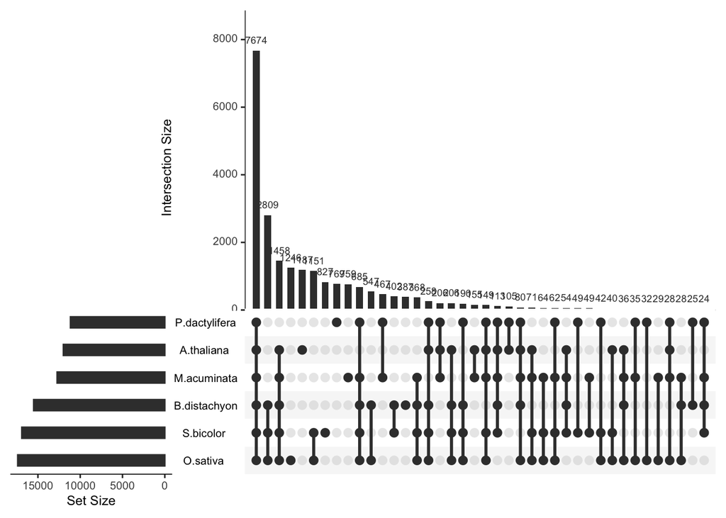

```r
upset(fromExpression(input),
      nintersects = 40,
      nsets = 6,
      order.by = "freq",
      decreasing = T,
      mb.ratio = c(0.6, 0.4),
      number.angles = 0,
      text.scale = 1.1,
      point.size = 2.8,
      line.size = 1
      )
```

#### Notes:

The data format here is not really feasible for large complex work. Would be incredibly difficult to create and format.

### Add the second package

Note that the upset command from complex-upset overrides the one from upsetr above.

```r
if(!require(ComplexUpset)){
  devtools::install_github("krassowski/complex-upset")
  library(ComplexUpset)
}
```

```r
if(!require(ggplot2)){
  install.packages("ggplot2")
  library(ggplot2)
}
if(!require(ggbeeswarm)){
  install.packages("ggbeeswarm")
  library(ggbeeswarm)
}
if(!require(ggplot2movies)){
  install.packages('ggplot2movies')
  library(ggplot2movies)
}
```

# complex-upset

[Package Git](https://github.com/krassowski/complex-upset). [data preparation advice](https://rdrr.io/github/krassowski/complex-upset/man/upset_data.html). [general readme](https://rdrr.io/github/krassowski/complex-upset/f/README.md)

### Run through Readme example

#### Get data

```r
# reads in a complex dataset of movies, including binary columns that give the genre
movies = ggplot2movies::movies

# create a list of the genre columns (i.e binary outcomes we want to plot)
genres = c('Action', 'Animation', 'Comedy', 'Drama', 'Documentary', 'Romance')

head(movies)
```

| title | year | length | budget | rating | votes | r1 | r2 | r3 | r4 | r5 | r6 | r7 | r8 | r9 | r10 | mpaa | Action | Animation | Comedy | Drama | Documentary | Romance | Short |
| --- | --- | --- | --- | --- | --- | --- | --- | --- | --- | --- | --- | --- | --- | --- | --- | --- | --- | --- | --- | --- | --- | --- | --- |
| $ | 1971 | 121 | NA | 6.4 | 348 | 4.5 | 4.5 | 4.5 | 4.5 | 14.5 | 24.5 | 24.5 | 14.5 | 4.5 | 4.5 |  | 0 | 0 | 1 | 1 | 0 | 0 | 0 |
| $1000 a Touchdown | 1939 | 71 | NA | 6.0 | 20 | 0.0 | 14.5 | 4.5 | 24.5 | 14.5 | 14.5 | 14.5 | 4.5 | 4.5 | 14.5 |  | 0 | 0 | 1 | 0 | 0 | 0 | 0 |
| $21 a Day Once a Month | 1941 | 7 | NA | 8.2 | 5 | 0.0 | 0.0 | 0.0 | 0.0 | 0.0 | 24.5 | 0.0 | 44.5 | 24.5 | 24.5 |  | 0 | 1 | 0 | 0 | 0 | 0 | 1 |
| $40,000 | 1996 | 70 | NA | 8.2 | 6 | 14.5 | 0.0 | 0.0 | 0.0 | 0.0 | 0.0 | 0.0 | 0.0 | 34.5 | 45.5 |  | 0 | 0 | 1 | 0 | 0 | 0 | 0 |
| $50,000 Climax Show, The | 1975 | 71 | NA | 3.4 | 17 | 24.5 | 4.5 | 0.0 | 14.5 | 14.5 | 4.5 | 0.0 | 0.0 | 0.0 | 24.5 |  | 0 | 0 | 0 | 0 | 0 | 0 | 0 |
| $pent | 2000 | 91 | NA | 4.3 | 45 | 4.5 | 4.5 | 4.5 | 14.5 | 14.5 | 14.5 | 4.5 | 4.5 | 14.5 | 14.5 |  | 0 | 0 | 0 | 1 | 0 | 0 | 0 |

### Create the plot

This is the most complex version of the plot, it includes 3 different plots on top of the different sets.

```
## [1] "Converting non-logical columns to binary: Action, Animation, Comedy, Drama, Documentary, Romance"
```

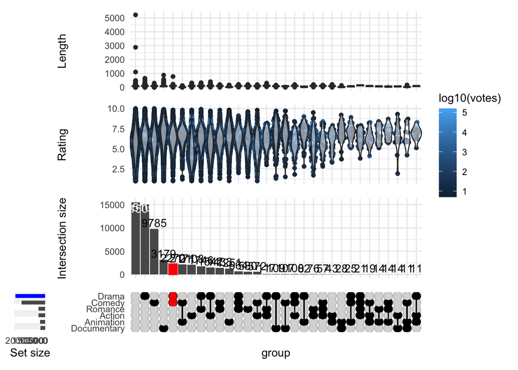

```r
upset(
    movies,
    genres,
    annotations = list(
        'Length'=list(
            aes=aes(x=intersection, y=length),
            geom=geom_boxplot()
        ),
        'Rating'=list(
            aes=aes(x=intersection, y=rating),
            geom=list(
                # if you do not want to install ggbeeswarm, you can use geom_jitter
                ggbeeswarm::geom_quasirandom(aes(color=log10(votes))),
                geom_violin(width=1.1, alpha=0.5)
            )
        )
    ),
    queries=list(
        upset_query(
            intersect=c('Drama', 'Comedy'),
            color='red',
            fill='red',
            only_components=c('intersections_matrix', 'Intersection size')
        ),
        upset_query(
            set='Drama',
            fill='blue'
        ),
        upset_query(
            intersect=c('Romance', 'Drama'),
            fill='yellow',
            only_components=c('Length')
        )
    ),
    min_size=10,
    width_ratio=0.1
)
```

This is simplified to just the upset we are after, but with some fun formatting

```r
upset(
    movies,
    genres,
    queries=list(
        upset_query(
            intersect=c('Drama', 'Comedy'),
            color='red',
            fill='red',
            only_components=c('intersections_matrix', 'Intersection size')
        ),
        upset_query(
            set='Drama',
            fill='blue'
        ),
        upset_query(
            intersect=c('Romance', 'Drama'),
            fill='yellow',
            only_components=c('Length')
        )
    ),
    min_size=10,
    width_ratio=0.1
)
```

```
## [1] "Converting non-logical columns to binary: Action, Animation, Comedy, Drama, Documentary, Romance"
```

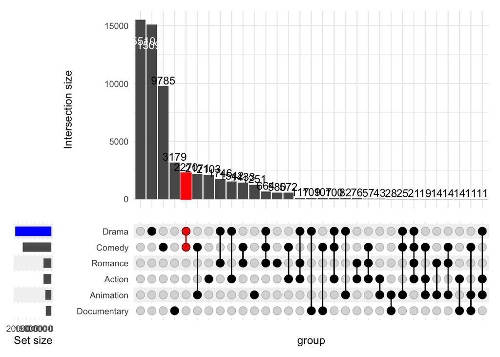

```r
upset(
    movies,
    genres,
    min_size=10,
    width_ratio=0.1
)
```

```
## [1] "Converting non-logical columns to binary: Action, Animation, Comedy, Drama, Documentary, Romance"
```

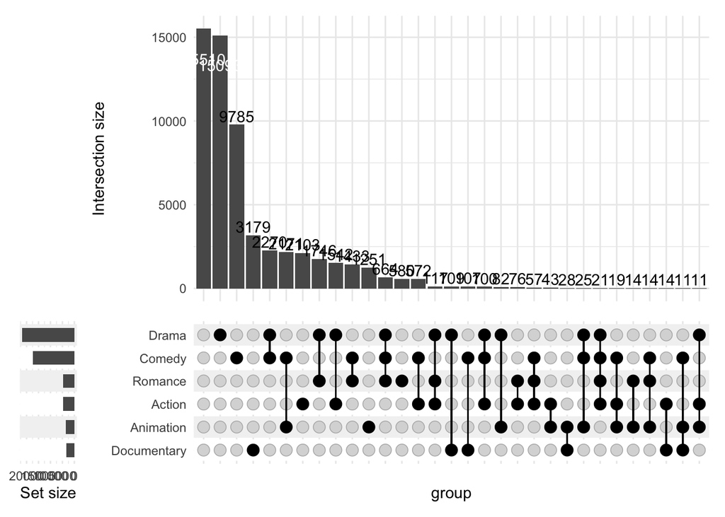

### Run a test example using Complex upset

### Simulate data conforming to package requirements

Require binary columns representing group membership

```r
complex_simdat <- data.frame(replicate(10,sample(0:1,1000,rep=TRUE)))

head(complex_simdat)
```

|  | X1 | X2 | X3 | X4 | X5 | X6 | X7 | X8 | X9 | X10 |
| --- | --- | --- | --- | --- | --- | --- | --- | --- | --- | --- |
| 1 | 1 | 0 | 0 | 0 | 0 | 0 | 0 | 0 | 0 | 1 |
| 2 | 1 | 1 | 1 | 1 | 0 | 1 | 1 | 0 | 0 | 0 |
| 3 | 1 | 0 | 0 | 1 | 0 | 0 | 1 | 1 | 0 | 0 |
| 4 | 0 | 1 | 1 | 1 | 0 | 0 | 0 | 1 | 1 | 1 |
| 5 | 1 | 1 | 1 | 1 | 1 | 1 | 0 | 0 | 0 | 1 |
| 6 | 0 | 0 | 1 | 0 | 1 | 1 | 1 | 0 | 1 | 0 |

#### try run the simplest version with this simulated data

```r
setlist <- c("X2","X4","X7","X8","X9")
```

```r
upset(
  complex_simdat,
    setlist,
    min_size=10,
    width_ratio=0.1)
```

```
## [1] "Converting non-logical columns to binary: X2, X4, X7, X8, X9"
```

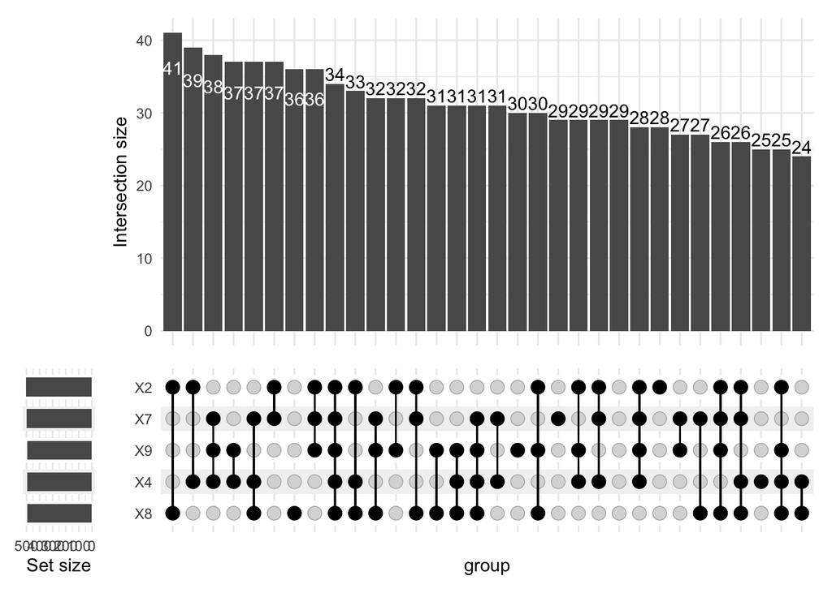

## NOTES

Works really well. Easy to reproduce data set. Matches real life data formats. Havent tried to edit and add, but probably can easily enough.